# Plotting Tutorial

Applied Longitudinal Data Analysis

Emorie D Beck

19. September 2019

[Download .Rmd (won’t work in Safari or IE)](https://raw.githubusercontent.com/emoriebeck/R-tutorials/master/ALDA/week_4_plotting/week_4_plotting.Rmd)  
[See GitHub Repository](https://github.com/emoriebeck/R-tutorials/tree/master/ALDA/week_4_plotting)

# Workspace

## Packages

First let’s load in our packages. We’re going to load in a couple of extras (`brms` and `tidybayes`) that we haven’t used before. These will let us make some pretty plots later.

```r
library(psych)
library(knitr)
library(kableExtra)
library(lme4)
library(broom.mixed)
library(brms)
library(tidybayes)
library(plyr)
library(tidyverse)

data_path <- "https://github.com/emoriebeck/R-tutorials/raw/master"
```

## Read in Data

The National Longitudinal Study of Youths 1979 Child and Young Adult Sample (NLSYCYA) is a longitudinal study conducted by the National Bureau of Labor Statistics. The sample includes the children of the original 1979 sample, of which we will use a small subset. Here, we are going to use a subset of the more than 11,000 variables available that include the following:

| Item Name | Description | Time-Varying? |
| --- | --- | --- |
| PROC_CID | Participant ID | No |
| Dem_DOB | Year of Date of Birth | No |
| groups | Jail, Community Service, None | No |
| DemPWeight | Weight Percentile at age 10 | No |
| age | Age of participant | Yes |
| Year | Year of Survey | Yes |
| age0 | Age of participant (centered) | Yes |
| SensSeek | Sensation-Seeking Composite | Yes |
| CESD | CESD Depression Composite | Yes |

```r
load(url(sprintf("%s/ALDA/week_4_plotting/data/sample.RData", data_path)))

sample_dat
```

| PROC_CID | age | year | age0 | groups | CESD | SensSeek | DemPweight |
| --- | --- | --- | --- | --- | --- | --- | --- |
| 1601 | 16 | 2006 | 2 | CommServ | 0.42857143 | 3.666667 | 0.815939875 |
| 1601 | 18 | 2008 | 4 | CommServ | 2.00000000 | 3.000000 | 0.815939875 |
| 9102 | 16 | 2012 | 2 | None | 0.18181818 | 3.333333 | 0.671239721 |
| 9501 | 14 | 2000 | 0 | Jail | 0.50000000 | 3.000000 | 0.547758426 |
| 9501 | 18 | 2004 | 4 | Jail | 0.42857143 | 3.000000 | 0.547758426 |
| 9501 | 22 | 2008 | 8 | Jail | 0.42857143 | 3.000000 | 0.547758426 |
| 9502 | 14 | 2002 | 0 | Jail | 0.14285714 | 3.000000 | 0.420740291 |
| 9502 | 16 | 2004 | 2 | Jail | 0.28571429 | 3.000000 | 0.420740291 |
| 9502 | 20 | 2008 | 6 | Jail | 0.00000000 | 3.000000 | 0.420740291 |
| 9503 | 16 | 2004 | 2 | Jail | 1.71428571 | 3.000000 | 0.031442763 |

[output cut: 2074 more lines]

## Restructure Data

These data are already largely cleaned as that is not our focus today. We just need to do a little bit of restructuring.

To run our models using `purrr`, we need to restrucutre the data to long. While we’re at it, we need to create a time variable centered at zero, so we can interpret our moderators later.

```r
(df1_long <- sample_dat %>%
  gather(key = trait, value = value, CESD, SensSeek, na.rm = T) %>%
   mutate(wave = year - 1996,
          age0 = age-16))
```

| PROC_CID | age | year | age0 | groups | DemPweight | trait | value | wave |
| --- | --- | --- | --- | --- | --- | --- | --- | --- |
| 1601 | 16 | 2006 | 0 | CommServ | 0.815939875 | CESD | 0.42857143 | 10 |
| 1601 | 18 | 2008 | 2 | CommServ | 0.815939875 | CESD | 2.00000000 | 12 |
| 9102 | 16 | 2012 | 0 | None | 0.671239721 | CESD | 0.18181818 | 16 |
| 9501 | 14 | 2000 | -2 | Jail | 0.547758426 | CESD | 0.50000000 | 4 |
| 9501 | 18 | 2004 | 2 | Jail | 0.547758426 | CESD | 0.42857143 | 8 |
| 9501 | 22 | 2008 | 6 | Jail | 0.547758426 | CESD | 0.42857143 | 12 |
| 9502 | 14 | 2002 | -2 | Jail | 0.420740291 | CESD | 0.14285714 | 6 |
| 9502 | 16 | 2004 | 0 | Jail | 0.420740291 | CESD | 0.28571429 | 8 |
| 9502 | 20 | 2008 | 4 | Jail | 0.420740291 | CESD | 0.00000000 | 12 |
| 9503 | 16 | 2004 | 0 | Jail | 0.031442763 | CESD | 1.71428571 | 8 |

[output cut: 4158 more lines]

# The Basic Growth Model

We’ll start with the basic growth model (just looking at change in a single variable over time).

we will use list columns to do it. We’ll start by using the `group_by()` and `nest()` functions from `dplyr` and `tidyr` to put the data for each trait into a cell of our data frame:

```r
(df1_nested <- df1_long %>%
  group_by(trait) %>%
  nest())
```

| trait | data |
| --- | --- |
| CESD |  |
| SensSeek |  |

Now, our data frame is 2 x 2, with the elements in the second column each containing the data frame that corresponds to that trait. This makes it really easy to run our models using the `map()` family of unctions from `purrr`.

Before we fit the full growth model, we will first fit the unconditional model. Below, we will add a new column to our data frame that will contain the unconditional model for each trait.

In this case the model will be in the form of:

- **Level 1:** $Y_{ij} = \beta_{0j} + \varepsilon{ij}$
- **Level 2:**
- $\beta_{0j} = \gamma_{00} + U_{0j}$

```r
(df1_nested <- df1_nested %>%
  mutate(fit0 = map(data, ~lmer(value ~ 1 + (1 | PROC_CID), data = .))))
```

| trait | data | fit0 |
| --- | --- | --- |
| CESD |  |  |
| SensSeek |  |  |

Now we can see we have a new list column in our data frame called fit0 that contains an S4 class lmerMod, which simply means your growth model. To understand model, I personally find it easiest to visualize it. What this model is telling us is the mean across all observations as well as the between-person variability in that estimate.

Now, moving on to the growth model:

In this case the model will be in the form of:

- **Level 1:** $Y_{ij} = \beta_{0j} + \beta_{1j}*time_{ij} + \varepsilon{ij}$
- **Level 2:**
- $\beta_{0j} = \gamma_{00} + U_{0j}$
- $\beta_{1j} = \gamma_{10} + U_{1j}$

```r
(df1_nested <- df1_nested %>%
  mutate(fit2 = map(data, ~lmer(value ~ 1 + age0 + (age0 | PROC_CID), data = .))))
```

| trait | data | fit0 | fit2 |
| --- | --- | --- | --- |
| CESD |  |  |  |
| SensSeek |  |  |  |

Now that we’ve run our model, we are ready to plot the results.

To do so, we’ll write a short function that will get the predicted values both for group level effects, as well as for individual-level estimates. There’s also a hidden function for getting standard errors of our pointwise estimates that we’ll use to create confidence bands in our plots. Don’t worry about that.

```r
fixed_pred_fun <- function(m){
  frame <- tibble(Intercept = 1, age0 = seq(0, 8, .1)) %>%
    mutate(fixed_pred = predict(m, newdata = ., re.form = NA),
           age = age0 + 16)
  frame$SE <- pv_fun(frame %>% select(Intercept, age0), m)
  frame %>% select(-Intercept)
}

ran_pred_fun <- function(m){
  crossing(age0 = seq(0, 8, 1),
         PROC_CID = m@frame$PROC_CID) %>%
    mutate(ran_pred = predict(m, newdata = .),
           age = age0 + 16)
}

(df1_nested <- df1_nested %>%
  mutate(fixed_pred = map(fit2, fixed_pred_fun),
         ran_pred = map(fit2, ran_pred_fun),
         combined_pred = map2(fixed_pred, ran_pred, full_join)))
```

| trait | data | fit0 | fit2 | fixed_pred | ran_pred | combined_pred |
| --- | --- | --- | --- | --- | --- | --- |
| CESD |  |  |  |  |  |  |
| SensSeek |  |  |  |  |  |  |

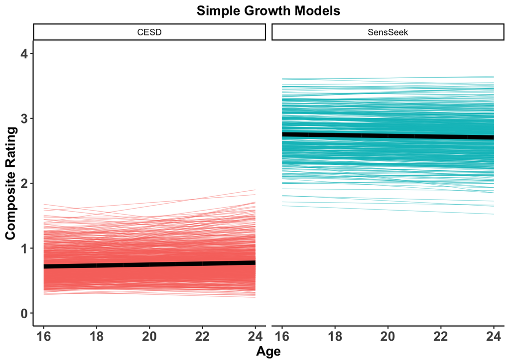

```r
df1_nested %>%
  select(trait, combined_pred) %>%
  unnest(combined_pred) %>%
  ggplot(aes(x = age)) +
    geom_line(aes(y = ran_pred, color = trait, group = PROC_CID), size = .25, alpha = .5) +
    geom_line(aes(y = fixed_pred), size = 2) +
    lims(y = c(0,4)) +
    labs(x = "Age", y = "Composite Rating",
         title = "Simple Growth Models") +
    facet_grid(~trait) +
    theme_classic() +
    theme(axis.text = element_text(face = "bold", size = rel(1.2)),
          axis.title = element_text(face = "bold", size = rel(1.2)),
          legend.title = element_text(face = "bold", size = rel(1.2)),
          legend.position = "none",
          plot.title = element_text(face = "bold", size = rel(1.2), hjust = .5))
```

And with confidence bands:

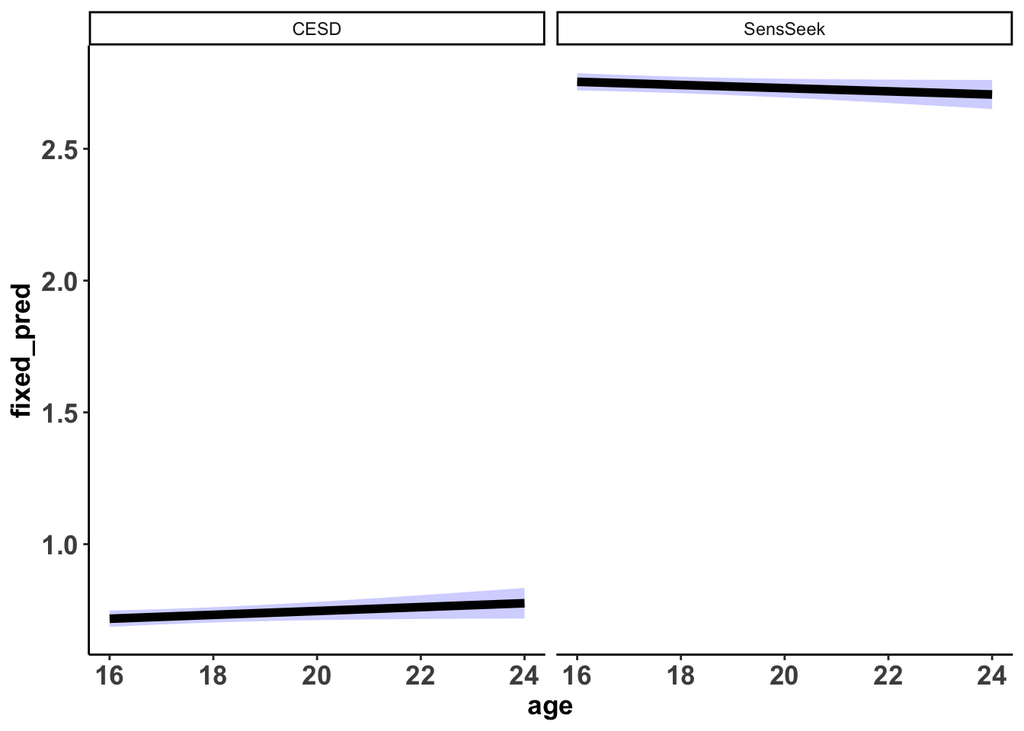

```r
df1_nested %>%
  mutate(df = map_dbl(fit2, df.residual)) %>%
  select(trait, fixed_pred, df) %>%
  unnest(fixed_pred) %>%
  ggplot(aes(x = age, y = fixed_pred, fill = trait)) +
    geom_ribbon(aes(ymin=fixed_pred-1.96*SE,ymax=fixed_pred+1.96*SE),alpha=0.2,fill="blue") +
    geom_line(size = 2) +
    facet_grid(~trait) +
    theme_classic() +
    theme(axis.text = element_text(face = "bold", size = rel(1.2)),
          axis.title = element_text(face = "bold", size = rel(1.2)),
          legend.title = element_text(face = "bold", size = rel(1.2)),
          legend.position = "none",
          plot.title = element_text(face = "bold", size = rel(1.2), hjust = .5))
```

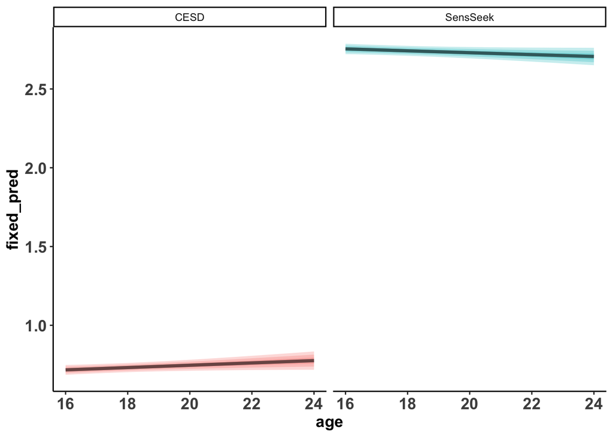

```r
df1_nested %>%
  mutate(df = map_dbl(fit2, df.residual)) %>%
  select(trait, fixed_pred, df) %>%
  unnest(fixed_pred) %>%
  ggplot(aes(x = age, y = fixed_pred, fill = trait)) +
    stat_dist_lineribbon(
      aes(dist = "student_t", arg1 = unique(df), arg2 = fixed_pred, arg3 = SE),
      alpha = 1/4
    ) +
    facet_grid(~trait) +
    theme_classic() +
    theme(axis.text = element_text(face = "bold", size = rel(1.2)),
          axis.title = element_text(face = "bold", size = rel(1.2)),
          legend.title = element_text(face = "bold", size = rel(1.2)),
          legend.position = "none",
          plot.title = element_text(face = "bold", size = rel(1.2), hjust = .5))
```

## Two-Level Categorical Moderator

Let’s start with the basic syntax:

- **Level 1:** $Y_{ij} = \beta_{0j} + \beta_{1j}*time_{1j} + \varepsilon{ij}$
- **Level 2:**
- $\beta_{0j} = \gamma_{00} + \gamma_{01}*X_{2j} + U_{0j}$
- $\beta_{1j} = \gamma_{10} + \gamma_{11}*X_{2j} + U_{1j}$

Now let’s swap that out for a 2 group sample from the present data:

- **Level 1:** $Y_{ij} = \beta_{0j} + \beta_{1j}*age0_{ij} + \varepsilon{ij}$
- **Level 2:**
- $\beta_{0j} = \gamma_{00} + \gamma_{01}*groupsNone + U_{0j}$
- $\beta_{1j} = \gamma_{10} + \gamma_{11}*groupsNone + U_{1j}$

| Variable | D1 |
| --- | --- |
| Jail | 0 |
| None | 1 |

```r
df1_nested <- df1_nested %>%
  mutate(data_2g = map(data, function(x) x %>% filter(groups != "CommServ")),
         fit3 = map(data_2g, ~lmer(value ~ 1 + age0*groups + (age0 | PROC_CID), data = .)))
```

When we plot these, we are plotting the simple slopes. Subbing 1 and 0 into the equations above we end up with the following for the groups.

```r
fixed_pred_fun <- function(m){
  frame <- crossing(Intercept = 1, age0 = seq(0, 8, .1),
           groups = c("Jail", "None")) %>%
    mutate(fixed_pred = predict(m, newdata = ., re.form = NA),
           age = age0 + 16,
           groupsn = as.numeric(mapvalues(groups, unique(groups), c(1,0))),
           Int = age0*groupsn)
  frame$SE <- pv_fun(frame %>% select(Intercept, age0, groupsn, Int), m)
  frame %>% select(-Intercept, -groupsn, -Int)
}

fixed_pred_fun <- function(m){
  crossing(age0 = seq(0, 8, 1),
           groups = c("Jail", "None")) %>%
    mutate(fixed_pred = predict(m, newdata = ., re.form = NA),
           age = age0 + 16)
}

ran_pred_fun <- function(m){
  crossing(age0 = seq(0, 8, 1),
         PROC_CID = m@frame$PROC_CID) %>%
    left_join(m@frame %>% tbl_df %>% select(PROC_CID, groups)) %>%
    distinct() %>%
    mutate(ran_pred = predict(m, newdata = .),
           age = age0 + 16)
}

(df1_nested <- df1_nested %>%
  mutate(fixed_pred3 = map(fit3, fixed_pred_fun),
         ran_pred3 = map(fit3, ran_pred_fun),
         combined_pred3 = map2(fixed_pred3, ran_pred3, full_join)))
```

| trait | data | fit0 | fit2 | fixed_pred | ran_pred | combined_pred | data_2g | fit3 | fixed_pred3 | ran_pred3 | combined_pred3 |
| --- | --- | --- | --- | --- | --- | --- | --- | --- | --- | --- | --- |
| CESD |  |  |  |  |  |  |  |  |  |  |  |
| SensSeek |  |  |  |  |  |  |  |  |  |  |  |

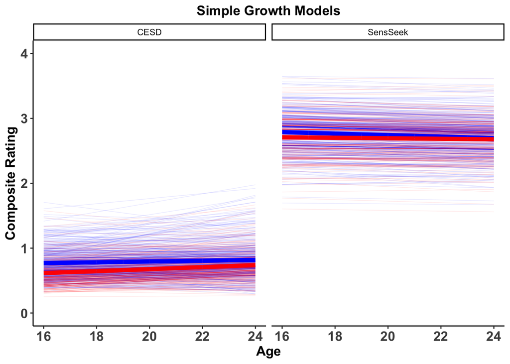

```r
df1_nested %>%
  select(trait, combined_pred3) %>%
  unnest(combined_pred3) %>%
  ggplot(aes(x = age)) +
    scale_color_manual(values = c("blue", "red")) +
    geom_line(aes(y = ran_pred, color = groups, group = PROC_CID), size = .25, alpha = .1) +
    geom_line(aes(y = fixed_pred, color = groups), size = 2) +
    lims(y = c(0,4)) +
    labs(x = "Age", y = "Composite Rating",
         title = "Simple Growth Models") +
    facet_grid(~trait) +
    theme_classic() +
    theme(axis.text = element_text(face = "bold", size = rel(1.2)),
          axis.title = element_text(face = "bold", size = rel(1.2)),
          legend.title = element_text(face = "bold", size = rel(1.2)),
          legend.position = "none",
          plot.title = element_text(face = "bold", size = rel(1.2), hjust = .5))
```

## Three-Level Categorical Moderator

- **Level 1:** $Y_{ij} = \beta_{0j} + \beta_{1j}*age0_{ij} + \varepsilon{ij}$
- **Level 2:**
- $\beta_{0j} = \gamma_{00} + \gamma_{01}*D1 + \gamma_{02}*D2 + U_{0j}$
- $\beta_{1j} = \gamma_{10} + \gamma_{11}*D1 + \gamma_{12}*D2 + U_{1j}$

| Variable | D1 | D2 |
| --- | --- | --- |
| Jail | 0 | 0 |
| None | 1 | 0 |
| CommServ | 0 | 1 |

```r
df1_nested <- df1_nested %>%
  mutate(fit4 = map(data, ~lmer(value ~ 1 + age0*groups + (age0 | PROC_CID), data = .)))
```

When we plot these, we are plotting the simple slopes. Subbing 1 and 0 into the equations above we end up with the following for the groups.

```r
fixed_pred_fun <- function(m){
  crossing(age0 = seq(0, 8, 1),
           groups = c("Jail", "None", "CommServ")) %>%
    mutate(fixed_pred = predict(m, newdata = ., re.form = NA),
           age = age0 + 16)
}

ran_pred_fun <- function(m){
  crossing(age0 = seq(0, 8, 1),
         PROC_CID = m@frame$PROC_CID) %>%
    left_join(m@frame %>% tbl_df %>% select(PROC_CID, groups)) %>%
    distinct() %>%
    mutate(ran_pred = predict(m, newdata = .),
           age = age0 + 16)
}

(df1_nested <- df1_nested %>%
  mutate(fixed_pred4 = map(fit4, fixed_pred_fun),
         ran_pred4 = map(fit4, ran_pred_fun),
         combined_pred4 = map2(fixed_pred4, ran_pred4, full_join)))
```

| trait | data | fit0 | fit2 | fixed_pred | ran_pred | combined_pred | data_2g | fit3 | fixed_pred3 | ran_pred3 | combined_pred3 | fit4 | fixed_pred4 | ran_pred4 | combined_pred4 |
| --- | --- | --- | --- | --- | --- | --- | --- | --- | --- | --- | --- | --- | --- | --- | --- |
| CESD |  |  |  |  |  |  |  |  |  |  |  |  |  |  |  |
| SensSeek |  |  |  |  |  |  |  |  |  |  |  |  |  |  |  |

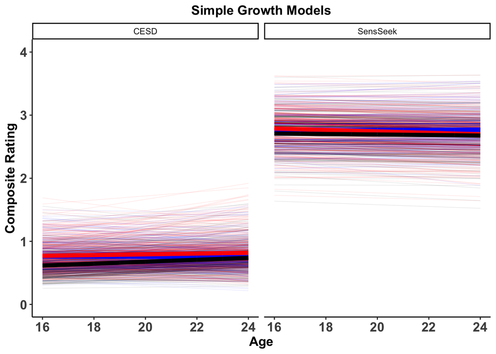

```r
df1_nested %>%
  select(trait, combined_pred4) %>%
  unnest(combined_pred4) %>%
  ggplot(aes(x = age)) +
    scale_color_manual(values = c("blue", "red", "black")) +
    geom_line(aes(y = ran_pred, color = groups, group = PROC_CID), size = .25, alpha = .1) +
    geom_line(aes(y = fixed_pred, color = groups), size = 2) +
    lims(y = c(0,4)) +
    labs(x = "Age", y = "Composite Rating",
         title = "Simple Growth Models") +
    facet_grid(~trait) +
    theme_classic() +
    theme(axis.text = element_text(face = "bold", size = rel(1.2)),
          axis.title = element_text(face = "bold", size = rel(1.2)),
          legend.title = element_text(face = "bold", size = rel(1.2)),
          legend.position = "none",
          plot.title = element_text(face = "bold", size = rel(1.2), hjust = .5))
```

## Continuous Time-Invariant Moderator

```r
df1_nested <- df1_nested %>%
  mutate(fit5 = map(data, ~lmer(value ~ 1 + age0*DemPweight + (age0 | PROC_CID), data = .)))
```

```r
fixed_pred_fun <- function(m){
  desc <- Rmisc::summarySE(m@frame, measurevar = "DemPweight")
    crossing(age0 = seq(0, 8, 1),
           DemPweight = c(desc$DemPweight - desc$sd,
                          desc$DemPweight,
                          desc$DemPweight + desc$sd)) %>%
    mutate(fixed_pred = predict(m, newdata = ., re.form = NA),
           age = age0 + 16,
           Weight = factor(DemPweight, levels = unique(DemPweight), labels = c("-1SD", "0SD", "1SD")))
}

ran_pred_fun <- function(m){
  crossing(age0 = seq(0, 8, 1),
         PROC_CID = m@frame$PROC_CID) %>%
    left_join(m@frame %>% tbl_df %>% select(PROC_CID, DemPweight)) %>%
    distinct() %>%
    mutate(ran_pred = predict(m, newdata = .),
           age = age0 + 16)
}

(df1_nested <- df1_nested %>%
  mutate(fixed_pred5 = map(fit5, fixed_pred_fun),
         ran_pred5 = map(fit5, ran_pred_fun),
         combined_pred5 = map2(fixed_pred5, ran_pred5, full_join)))
```

| trait | data | fit0 | fit2 | fixed_pred | ran_pred | combined_pred | data_2g | fit3 | fixed_pred3 | ran_pred3 | combined_pred3 | fit4 | fixed_pred4 | ran_pred4 | combined_pred4 | fit5 | fixed_pred5 | ran_pred5 | combined_pred5 |
| --- | --- | --- | --- | --- | --- | --- | --- | --- | --- | --- | --- | --- | --- | --- | --- | --- | --- | --- | --- |
| CESD |  |  |  |  |  |  |  |  |  |  |  |  |  |  |  |  |  |  |  |
| SensSeek |  |  |  |  |  |  |  |  |  |  |  |  |  |  |  |  |  |  |  |

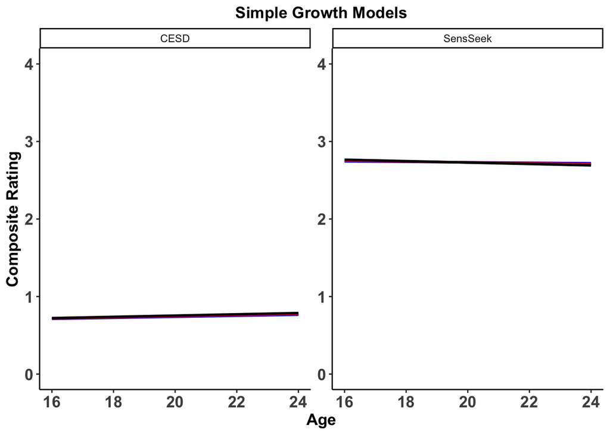

```r
df1_nested %>%
  select(trait, combined_pred5) %>%
  unnest(combined_pred5) %>%
  ggplot(aes(x = age)) +
    scale_color_manual(values = c("blue", "red", "black")) +
    # geom_line(aes(y = ran_pred, group = PROC_CID), size = .25, alpha = .1) +
    geom_line(aes(y = fixed_pred, color = Weight), size = 1) +
    lims(y = c(0,4)) +
    labs(x = "Age", y = "Composite Rating",
         title = "Simple Growth Models") +
    facet_wrap(~trait, scales = "free_y") +
    theme_classic() +
    theme(axis.text = element_text(face = "bold", size = rel(1.2)),
          axis.title = element_text(face = "bold", size = rel(1.2)),
          legend.title = element_text(face = "bold", size = rel(1.2)),
          legend.position = "none",
          plot.title = element_text(face = "bold", size = rel(1.2), hjust = .5))
```